# Feeding the models

- DGVMs require a parametrisation of the land surface
- ... at a coarse scale (10s-100s km)
- ... over large periods of time (decades!)
- But do we prescribe these parameters?
- Can we assess DGVM assumptions?
- Does EO help?

# How can EO help?

- Modelling of **energy fluxes**
  - Radiation budget
  - Photosynthesis
- We can interpret EO data in terms of
  - Same parameters
  - Same physical models
- We can either
  - Compare models with "reality"
  - Prescribe parameters for the model
- But remember that EO data was **limited**?

# Albedo (Bi-hemispherical reflectance)

- Albedo: fraction of incoming radiation that is **reflected**
- Consider **broad spectral bands**
- In MULTIPLY, aim to **infer** albedo from combining different sensors
  - Coarse spatial resolution
    - MODIS
    - S3/OLCI
    - S3/SLSTR
    - VIIRS
- Two measurements per time step per pixel: **VIS**ible and **N**ear**I**nfra**R**ed

[figure not shown]

# Interpreting albedo

- Use a simple model
  - ... which one can use inside a DGVM (Seller's, JRC-TIP, etc)
- Describe albedo as a function of
  - optical properties of soil
  - optical properties of leaves
  - Amount and structure of canopy
- Only that we simplify the structure $\longrightarrow$ **effective LAI**
- So, we have two (noisy!)observations...
  - ... and 7 parameters!
- How do we go about that?!!

# The model

- **JRC-TIP**
- 7 parameters $\longrightarrow$ predicts $\alpha_{VIS}$ & $\alpha_{NIR}$
- Simplify 3D structure to have simple physics
- We don't actually use the model
  - $\longrightarrow$ We use **emulators**
- The model is present in some DGVMs already
- ... or we could use another BHR model!

# Priors

- Need to limit the solution space!
- What are our parameters?
  - leaf reflectance and transmittance (VIS+NIR)
  - soil albedo (VIS+NIR)
  - effective LAI

# Leaves

[figure not shown]

# Setting up the problem

- First, we need some observations
  - Currently, using MODIS MCD43 Albedo product
  - Will use MULTIPLY coarse resolution product when available
- We also need a **state mask**
- And finally, our RT model is stored as an **emulator** in a file
  - If you want to change the RT model, you change the emulator file!

```python
import numpy as np
from kafka.input_output import BHRObservations, KafkaOutput

parameter_list = ["w_vis", "x_vis", "a_vis",
                     "w_nir", "x_nir", "a_nir", "TeLAI"]

tile = "h17v05"
start_time = "2017001"
emulator = "./SAIL_emulator_both_500trainingsamples.pkl"
mcd43a1_dir="/data/selene/ucfajlg/Ujia/MCD43/"

mask = np.zeros((2400,2400),dtype=np.bool8)
mask[650:730, 1180:1280] = True # Arros

bhr_data =  BHRObservations(emulator, tile, mcd43a1_dir, start_time,
                                end_time=None, mcd43a2_dir=None)
```

# The prior...

- We use a prior object, `JRCPrior`.
- This prior encodes the JRC TIP prior
- Prior is subjective: if you don't agree with it, you can set **your own**!

```python
the_prior = JRCPrior(parameter_list, mask)
```

So we have a prior, observations, a model (associated to the observations)...

What else do we need?

```
* We need a starting point
```

Currently MULTIPLY inference engine works as a **filter**

```
* It inverts observations **sequentially**
* We need to give it starting prior
* ... Which we can query the prior engine for
* The prior is defined as a
    * Mean vector $\vec{\mu}$, `x_forecast`
    * Prior **inverse** covariance matrix $\mathbf{C}_{prior}^{-1}$, `P_forecast_inv`
```

```
Number of inference pixels: 8000
Size of the state vector: 56000
Size of the inverse covariance matrix: 56000 * 56000
```

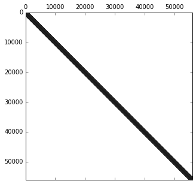

```python
# Query the JRC-TIP prior for a mean and inverse covariance matrix
x_forecast, P_forecast_inv = the_prior.process_prior(None)
print("Number of inference pixels: {:d}".format(mask.sum()))
print("Size of the state vector: {:d}".format(x_forecast.shape[0]))
print("Size of the inverse covariance matrix: {:d} * {:d}".format(
    P_forecast_inv.shape[0], P_forecast_inv.shape[1]))
plt.figure(figsize=(10,5))
plt.spy(P_forecast_inv, c="0.4", ms=5)
```

We have set everything set up, except for **when** we want the system to report an **inference**

- Observations are every 16 days
- Assume we want to invert every observation
- If we wanted (eg) daily estimates, the system could **interpolate** using a **dynamic temporal model**
- ... but not using it this time

So let's define the inference grid: a set of times when we will produced inferences

```python
base = datetime.datetime(2017,7,1)
num_days = 60
time_grid = list((base + datetime.timedelta(days=x)
                  for x in range(0, num_days, 16)))
print(time_grid)
```

```
[datetime.datetime(2017, 7, 1, 0, 0), datetime.datetime(2017, 7, 17, 0, 0), datetime.datetime(2017, 8, 2, 0, 0), datetime.datetime(2017, 8, 18, 0, 0)]
```

Nearly there!

This would be quite useless if we didn't set up somewhere to save the data.

In this case, we use GeoTIFF files for different parameters

```python
projection, geotransform = bhr_data.define_output()
output = KafkaOutput(parameter_list, geotransform, projection, "./")
```

```python
# Putting it all together
from kafka import LinearKalman
from kafka.inference import create_nonlinear_observation_operator

kf = LinearKalman(bhr_data, output, mask,
                      create_nonlinear_observation_operator, parameter_list,
                      state_propagation=None,
                      prior=the_prior,
                      linear=False)


Q = np.zeros_like(x_forecast)
kf.set_trajectory_model()
kf.set_trajectory_uncertainty(Q)


kf.run(time_grid, x_forecast, None, P_forecast_inv, iter_obs_op=True)
```

# Soo....

Do we have some results???

```python
ls -lh *198*tif
```

```
-rw-rw-r--. 1 ucfajlg ucfajlg 57K Feb  5 20:58 a_nir_A2017198.tif
-rw-rw-r--. 1 ucfajlg ucfajlg 58K Feb  5 20:58 a_nir_A2017198_unc.tif
-rw-rw-r--. 1 ucfajlg ucfajlg 58K Feb  5 20:58 a_vis_A2017198.tif
-rw-rw-r--. 1 ucfajlg ucfajlg 58K Feb  5 20:58 a_vis_A2017198_unc.tif
-rw-rw-r--. 1 ucfajlg ucfajlg 58K Feb  5 20:58 TeLAI_A2017198.tif
-rw-rw-r--. 1 ucfajlg ucfajlg 57K Feb  5 20:58 TeLAI_A2017198_unc.tif
-rw-rw-r--. 1 ucfajlg ucfajlg 57K Feb  5 20:58 w_nir_A2017198.tif
-rw-rw-r--. 1 ucfajlg ucfajlg 58K Feb  5 20:58 w_nir_A2017198_unc.tif
-rw-rw-r--. 1 ucfajlg ucfajlg 57K Feb  5 20:58 w_vis_A2017198.tif
-rw-rw-r--. 1 ucfajlg ucfajlg 57K Feb  5 20:58 w_vis_A2017198_unc.tif
-rw-rw-r--. 1 ucfajlg ucfajlg 57K Feb  5 20:58 x_nir_A2017198.tif
-rw-rw-r--. 1 ucfajlg ucfajlg 56K Feb  5 20:58 x_nir_A2017198_unc.tif
-rw-rw-r--. 1 ucfajlg ucfajlg 56K Feb  5 20:58 x_vis_A2017198.tif
-rw-rw-r--. 1 ucfajlg ucfajlg 57K Feb  5 20:58 x_vis_A2017198_unc.tif
```

So for each data, we have

- One GeoTIFF file with the retrieved parameter
- One GeoTIFF file with the associated uncertainty

You can open these files in any software package

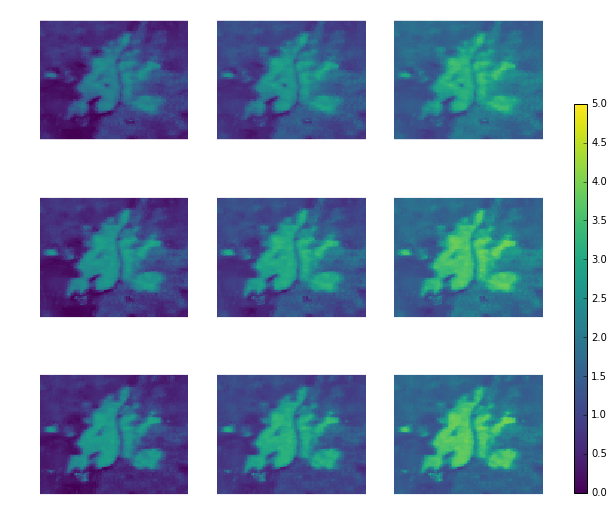

```python
plot_parameter("TeLAI")
```

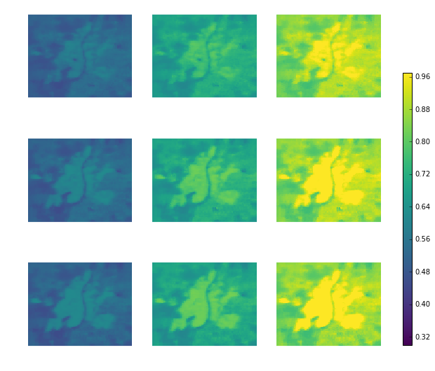

```python
plot_parameter("w_nir")
```

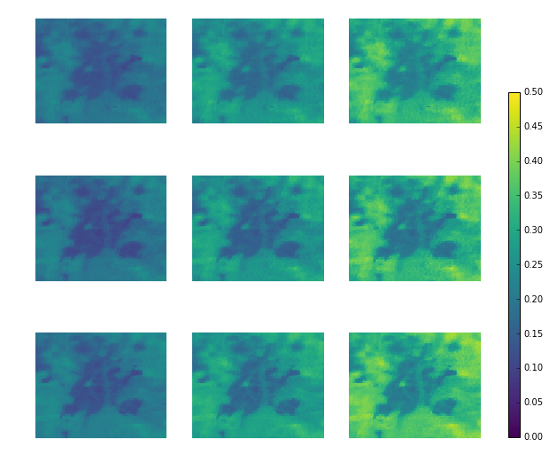

```python
plot_parameter("w_vis")
```

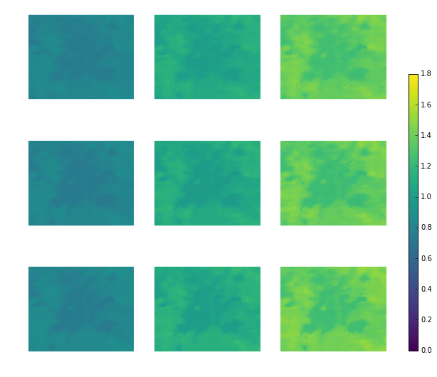

```python
plot_parameter("x_vis")
```

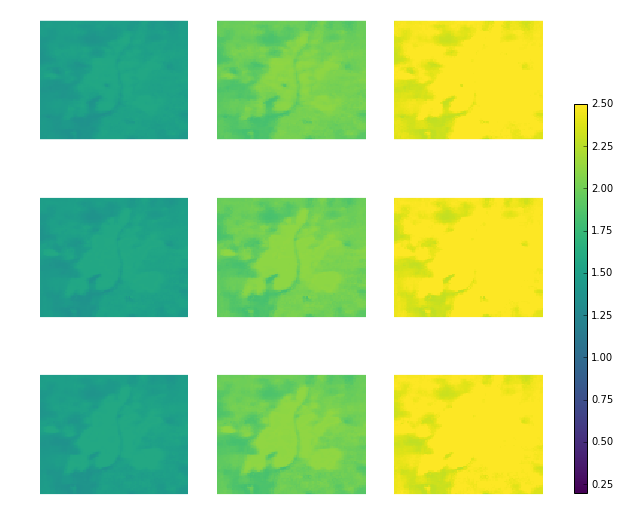

```python
plot_parameter('x_nir')
```

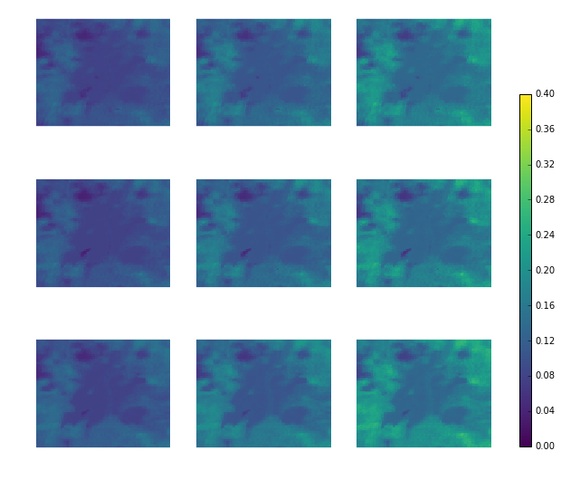

```python
plot_parameter("a_vis")
```

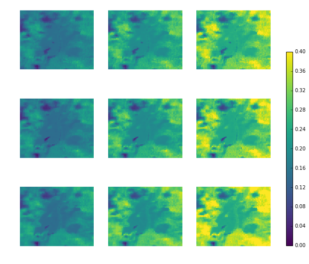

```python
plot_parameter("a_nir")
```

# Final remarks

- This is a simple application...
  - I haven't shown all the results $\longrightarrow$ creative approaches to visualisation
- The tools for other problems will be slightly different
  - ... but you'll always need:
    - a **PHYSICAL MODEL** (emulated usually)
    - a **PRIOR distribution**
    - Maybe a **DYNAMIC MODEL** to propagate parameter between timesteps
- This approach propagates the uncertainty
  - in the observations
  - in the physical model
  - $\longrightarrow$ traceability!